# National Excess Mortality from Sub-National data: Method and Application for Argentina

Ariel Karlinsky

# Introduction

Main markdown for paper `National Excess Mortality from Sub-National data: Method and illustration for Argentina`. Using publicly available data on reported COVID-19 mortality and all-cause mortality in Argentina and Argentinian provinces, We derive a method to project national all-cause and excess mortality from sub-national data from the province of Cordoba.

# Data

Reported COVID-19 deaths by province and date:

```r
covid_by_province <- read_csv("Data/covid_deaths_by_province_date.csv")
```

All-Cause mortality data:

```r
acm_data <- read_csv("Data/acm_data.csv")
```

Expected monthly number of deaths in Argentina from World Mortality Dataset:

```r
argentina_pred_acm <- read_csv("https://raw.githubusercontent.com/dkobak/excess-mortality/main/baselines.csv",
                           col_names = c("country_name","month","pred_deaths")) %>%
  filter(country_name  == "Argentina")
```

Argentina reported COVID to WHO:

```r
who_covid_data_argentina <- read_csv("Data/who_covid_data_argentina.csv")
```

# Analsyis

Declare `acm_data` as `survey design` to implement the ratio estimator from `survey` package:

```r
acm_data_svy <- svydesign(data=acm_data %>%
                                   filter(year %in% c(2019,2020)),
                                 ids = ~1)
```

estimate ratio of deaths in Cordoba to Argentina, total:

```r
acm_ratio <- svyratio(~deaths_cor, ~deaths_arg,
                         design = acm_data_svy,
                         na.rm=TRUE)

acm_ratio_mean <- acm_ratio$ratio
acm_ratio_ci <- confint(acm_ratio, df = degf(acm_data_svy))
acm_ratio_lb <- acm_ratio_ci[1]
acm_ratio_ub <- acm_ratio_ci[2]

acm_ratio_mean
```

```
##            deaths_arg
## deaths_cor 0.09019308
```

```r
acm_ratio_ci
```

```
##                            2.5 %     97.5 %
## deaths_cor/deaths_arg 0.08695318 0.09343297
```

By year:

```r
acm_data_svy_2019 <- svydesign(data=acm_data %>%
                                   filter(year %in% c(2019)),
                                 ids = ~1)

acm_ratio_2019 <- svyratio(~deaths_cor, ~deaths_arg,
                         design = acm_data_svy_2019,
                         na.rm=TRUE)
acm_ratio_2019
```

```
## Ratio estimator: svyratio.survey.design2(~deaths_cor, ~deaths_arg, design = acm_data_svy_2019,
##     na.rm = TRUE)
## Ratios=
##            deaths_arg
## deaths_cor 0.09008843
## SEs=
##             deaths_arg
## deaths_cor 0.001865603
```

```r
acm_data_svy_2020 <- svydesign(data=acm_data %>%
                                   filter(year %in% c(2020)),
                                 ids = ~1)

acm_ratio_2020 <- svyratio(~deaths_cor, ~deaths_arg,
                         design = acm_data_svy_2020,
                         na.rm=TRUE)
acm_ratio_2020
```

```
## Ratio estimator: svyratio.survey.design2(~deaths_cor, ~deaths_arg, design = acm_data_svy_2020,
##     na.rm = TRUE)
## Ratios=
##            deaths_arg
## deaths_cor 0.09028615
## SEs=
##             deaths_arg
## deaths_cor 0.002529521
```

Create a new dataframe that contains the obsreved number of deaths in Argentina and Cordoba and the projection from Cordoba, merges with the expected number of deaths and derives estimates of excess.

```r
acm_proj <- acm_data %>%
  left_join(argentina_pred_acm, by = "month") %>%
  mutate(pred_deaths = if_else(year < 2020, NA_real_, pred_deaths),
         deaths_proj_acm = deaths_cor * (1/acm_ratio_mean),
         deaths_proj_ub = deaths_cor * (1/acm_ratio_lb),
         deaths_proj_lb = deaths_cor * (1/acm_ratio_ub),
         excess_deaths = deaths_proj_acm - pred_deaths,
         excess_deaths_ub = deaths_proj_ub - pred_deaths,
         excess_deaths_lb = deaths_proj_lb - pred_deaths,
         date = ym(glue("{year}-{month}")))
```

Compute total excess from March 2020 up to end of 2021

```r
total_excess <- acm_proj %>%
  filter(date >= "2020-03-01") %>%
  summarise(total_excess = sum(excess_deaths),
            total_excess_lb = sum(excess_deaths_lb),
            total_excess_ub = sum(excess_deaths_ub)) %>%
  relocate(total_excess_lb)

total_excess
```

```
## # A tibble: 1 x 3
##   total_excess_lb total_excess total_excess_ub
##             <dbl>        <dbl>           <dbl>
## 1         104509.      130679.         158799.
```

Compare to reported COVID-19:

```r
who_total_covid_deaths <- who_covid_data_argentina %>%
  filter(date == "2021-12-31") %>%
  select(country, date, covid_deaths) %>%
  pull(covid_deaths)

who_total_covid_deaths
```

```
## [1] 117111
```

COVID-19 undercount:

```r
undercount <- total_excess$total_excess / who_total_covid_deaths

undercount
```

```
## [1] 1.115855
```

# Plots

## Figure 1

Left panel: share of ACM between Cordoba and National:

```r
plot_death_shares <- acm_data %>%
  filter(!is.na(deaths_ratio)) %>%
  ungroup() %>%
  ggplot(aes(x = date, y = deaths_ratio)) +
  geom_col(fill = "dodgerblue1") +
  geom_hline(yintercept = acm_ratio_mean,
             linetype = "dashed") +
  scale_x_date(breaks = seq(as.Date("2019-01-01"), as.Date("2020-12-31"), by="2 months"),
                labels = function(x) if_else(is.na(lag(x)) | !year(lag(x)) == year(x),
                                             paste(month(x, label = TRUE), "\n", year(x)),
                                             paste(month(x, label = TRUE))),
                expand = expansion(0.01)) +
  scale_y_continuous(labels = percent, expand = expansion(mult = c(0,0.10)),
                     breaks = seq(from = 0, to = 0.1, by = 0.025)) +
  annotate(geom="text", label=percent(acm_ratio_mean, accuracy = 0.1),
           x=as.Date("2019-01-15"),
           y=acm_ratio_mean, vjust=-0.5, hjust = 0.25) +
  labs(#title = "Monthly Ratio between Deaths in Córdoba Province to Total Deaths in Argentina",
       y = "Ratio between deaths in Córdoba to Argentina",
       x = "Month") +
  theme(axis.title = element_text(size = 10))
```

Right panel: Cordoba vs not Cordoba - daily COVID deaths

```r
plot_covid_province <- covid_by_province %>%
  mutate(cordoba = if_else(residencia_provincia_nombre == "Córdoba", "Córdoba", "Rest of Argentina")) %>%
  group_by(cordoba, fecha_fallecimiento) %>%
  filter(fecha_fallecimiento < "2022-01-01") %>%
  filter(fecha_fallecimiento > "2020-03-01") %>%
  summarise(covid_deaths = sum(n)) %>%
  group_by(cordoba) %>%
  mutate(ma7 = zoo::rollmean(covid_deaths, k = 7, align = "right", na.pad=TRUE)) %>%
  ggplot(aes(x= fecha_fallecimiento, y = ma7)) +
  geom_vline(xintercept = as.Date("2021-01-01"),
             linetype = "dashed") +
  geom_line(color = "firebrick1", size = 1) +
  facet_wrap(~cordoba, scales = "free_y", ncol = 1) +
  scale_y_continuous(expand = expansion(mult = c(0, 0.1))) +
  scale_x_date(breaks = breaks_pretty(n = 10),
               date_labels = "%m-%y") +
  labs(#title = "COVID Deaths in Argentina by Province",
       y = "Daily COVID Deaths (7-day Moving Average)",
       x = "Day") +
  theme(axis.title = element_text(size = 10))
```

Figure 1:

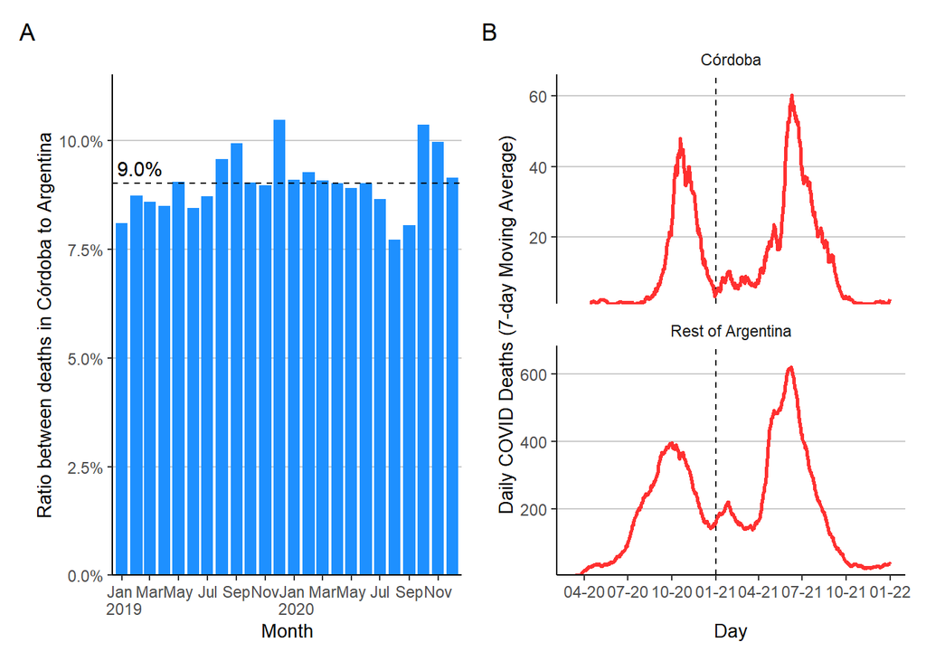

```r
plot_death_shares + plot_covid_province + plot_annotation(tag_levels = "A")
```

```r
ggsave("figure1.png",
       width = 180, units = "mm", dpi = 500)
```

## Figure 2

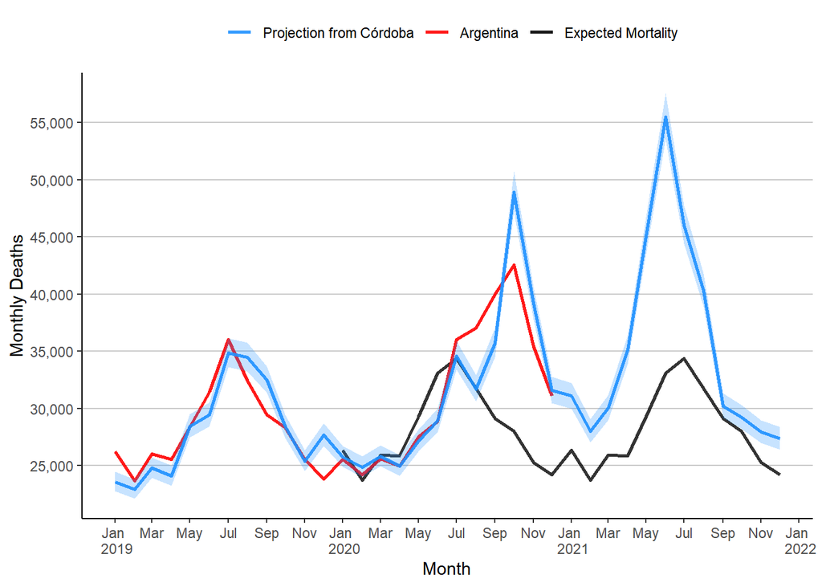

```r
colors <- c("Projection from Córdoba" = "dodgerblue1",
            "Argentina" = "red",
            "Expected Mortality" = "black")


acm_proj %>%
  filter(year >= 2019) %>%
  ggplot(aes(x = date, y = deaths_arg)) +
    geom_line(data = . %>% filter(year >= 2020),
            aes(y = pred_deaths), color = "black", size = 1, alpha = 0.8) +
  geom_line(size = 1, aes(color = "Argentina"), alpha = 0.9) +
  geom_line(aes(y = deaths_proj_acm), color = "dodgerblue1", size = 1, alpha = 0.9) +
  geom_ribbon(aes(ymin = deaths_proj_lb, ymax = deaths_proj_ub,
                  y = deaths_proj_acm),
              alpha = 0.25, fill = "dodgerblue1") +
  scale_x_date(date_breaks = "2 months",
                labels = function(x) if_else(is.na(lag(x)) | !year(lag(x)) == year(x),
                                             paste(month(x, label = TRUE), "\n", year(x)),
                                             paste(month(x, label = TRUE))),
                expand = expansion(0.05)) +
  scale_y_continuous(labels = comma, breaks = breaks_pretty(n = 6)) +
  scale_color_manual(values = colors) +
  labs(#title = "Monthly Deaths in Argentina 2019-2021",
       y = "Monthly Deaths",
       x = "Month",
       color = NULL) +
  theme(legend.position = "top")
```

```r
ggsave("figure2.png", width = 180, units = "mm", dpi = 500)
```